# Study of symmetric and asymmetric fission of Copernicium-284

### Author: Yuliia Hrabar (yuliia.hrabar@nuclear.lu.se)

## Table of content

- Abstract
- Importing python packages
- Reading simulation data from files
  - Extracting information from root trees
  - Loading data from a binary file
- Asymmetric fission case
  - Constructing a histogram for implantation detector
  - Constructing a histogram for box detectors
  - Energy deposited in implantation vs box detectors
    - Events that were registered both at implantation detector and box detectors at the same time
    - All events registered at the implantation detector and box detectors
- Results of all simulations
  - Plot selected simulation
  - Plots of all simulations
  - Conlusion

## Abstract

The purpose of this *jupyter notebook* is to analyze the data produced from simulating spontaneous fission of an alpha decay product Copernicium-284 of Super Heavy Element (SHE) Flevorium-288 and [TASISpec detector setup](https://portal.research.lu.se/portal/files/3183833/4004479.pdf).

The data was produced by simulating TASISpec with fission products of Cn-284 in [Geant4](https://geant4.web.cern.ch/). Geant4 is a toolkit for simulating the passage of particles through matter. TASISpec setup combines composite Ge- and Si-detectors (shown on Figure 1 in blue and surrounded by green respectively) for a new detector setup aimed towards multi-coincidence gamma -ray, X-ray, conversion electron, fission fragment, and a-particle spectroscopy of the heaviest nuclei.

[figure not shown]

Figure 1 - The full virtual TASISpec setup. All the Ge-crystals are depicted in blue and Si-detectors are surrounded by green colour. [2]

Main detectors of interest from the TASISpec setup for the simulation of fission products are four double-sided silicon strip detectors (DSSSDs) constructing a 'box detector' and one DSSSD facing a particle beam line - an 'implantation detector' (Figure 2).

[figure not shown]

Figure 2 - Si-detectors: the implantation detector and box DSSSDs. [2]

Fission of Cn-284 was simulated in Geant4 in the following way: two fission products were implanted in the implantation detector with a random position. Vector of momentum direction was randomly assigned to one fission product and the second fission product had momentum direction opposite to the first one. 3x3 scenarios were simulated - two cases of asymmetric fission (A1/A2 = 0.37 and 0.62) and one case of symmetric fission (A1/A2 = 1) for total kinetic energies of 225, 250 and 275 MeV. Parameters such as atomic number, mass number and kinetic energies of fission fragments used for the scenarios are presented in the following table.

[output not shown]

1. Read simulated data from ROOT files into pandas DataFrame
2. Maniplate and group data to plot histograms for implantation and box detectors
3. Maniplate and group data to plot energy deposited in the implant detector vs. box detectors

**References**  
[1] M. Albertsson, B. G. Carlsson, et al., Calculated fission-fragment mass yields and average total kinetic energies of heavy and superheavy nuclei, Eur. Phys. J. A (2020) 56: 46  
[2] L.G.Sarmiento, L.-L.Andersson, D.Rudolph, A Geant4 simulation package for the TASISpec experimental detector setup, Elsevier, (2012) 667: 26-31

## Loading data from a binary file

```python
data
```

| TKE | A1 | A2 | Event | Energy | DetID |
| --- | --- | --- | --- | --- | --- |
| 275.0 | 142.0 | 142.0 | 0.0 | 194026.558304 | 593.0 |
|  |  | 142.0 | 0.0 | 21016.307741 | 1209.0 |
|  |  | 142.0 | 1.0 | 201667.370187 | 878.0 |
|  |  | 142.0 | 1.0 | 3609.370434 | 1919.0 |
|  |  | 142.0 | 2.0 | 198400.728601 | 496.0 |
| ... | ... | ... | ... | ... | ... |
| 225.0 | 109.0 | 175.0 | 2490.0 | 27263.896950 | 1468.0 |
|  |  | 175.0 | 2491.0 | 182485.562287 | 494.0 |
|  |  | 175.0 | 2492.0 | 197704.526139 | 594.0 |
|  |  | 175.0 | 2493.0 | 138511.989400 | 558.0 |
|  |  | 175.0 | 2493.0 | 29125.560690 | 1933.0 |

30071 rows × 3 columns

# Asymmetric fission case

## Constructing a histogram for implantation detector

Choose energies detected in the implantation detector. Implantation detector is divided into 1024 pixels sensible for particle hits. Therefore, to get hits in the implantation detectors only entries with **DetID** < 1024 are selected.

```python
E_imp_histo = (asymm225.loc[asymm225['DetID']<1024].Energy)
```

Plot energy spectrum of the implantation detector with `pandas.DataFrame.plot.hist`.

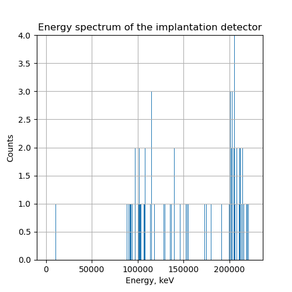

```python
plt.figure(num=None, figsize=(5, 5))
ax_imp = E_imp_histo.plot.hist(grid=True,bins=10000)
ax_imp.set(title = 'Energy spectrum of the implantation detector', xlabel = 'Energy, keV', ylabel = 'Counts')
ax_imp.set_ylim([0,4])
plt.savefig('output/implant_histogram.eps', format='eps', dpi=300)
```

## Energy deposited in implantation vs box detectors

Extract energies for the implantation detector and sum them for the same event.

```python
df_imp = asymm225.loc[asymm225['DetID']<1024].groupby(['Event'], sort=False).Energy.sum()
df_imp
```

```
Event
0.0       204701.274291
1.0       210576.180404
2.0       203917.364536
3.0       225000.000000
4.0        90427.887638
              ...
2490.0    204768.379839
2491.0    225000.000000
2492.0    225000.000000
2493.0    111940.697828
2494.0    105365.460921
Name: Energy, Length: 2495, dtype: float64
```

Extract energies for the box detectors and sum them for the same event

```python
df_box = (asymm225.loc[(asymm225['DetID']>1024) & (asymm225['DetID']<2048)]).groupby(['Event'], sort=False).Energy.sum()
df_box
```

```
Event
6.0       13003.177303
7.0       46774.410964
8.0       73653.494860
10.0      51774.535583
14.0      45167.071860
              ...
2470.0    42475.820865
2476.0    85216.806722
2479.0    61416.691818
2493.0    67817.177503
2494.0    72562.864414
Name: Energy, Length: 755, dtype: float64
```

### Events that were registered both at implantation detector and box detectors at the same time

Join DataFrames for the implantation and box detectors based on the event

```python
df_imp_box = pd.merge(df_box, df_imp, on='Event', suffixes=('_box', '_imp'))
df_imp_box
```

| Event | Energy_box | Energy_imp |
| --- | --- | --- |
| 6.0 | 13003.177303 | 155254.869971 |
| 7.0 | 46774.410964 | 126074.036881 |
| 8.0 | 73653.494860 | 102015.976700 |
| 10.0 | 51774.535583 | 121430.387101 |
| 14.0 | 45167.071860 | 126172.336153 |
| ... | ... | ... |
| 2470.0 | 42475.820865 | 130610.909625 |
| 2476.0 | 85216.806722 | 94865.035566 |
| 2479.0 | 61416.691818 | 114149.855479 |
| 2493.0 | 67817.177503 | 111940.697828 |
| 2494.0 | 72562.864414 | 105365.460921 |

755 rows × 2 columns

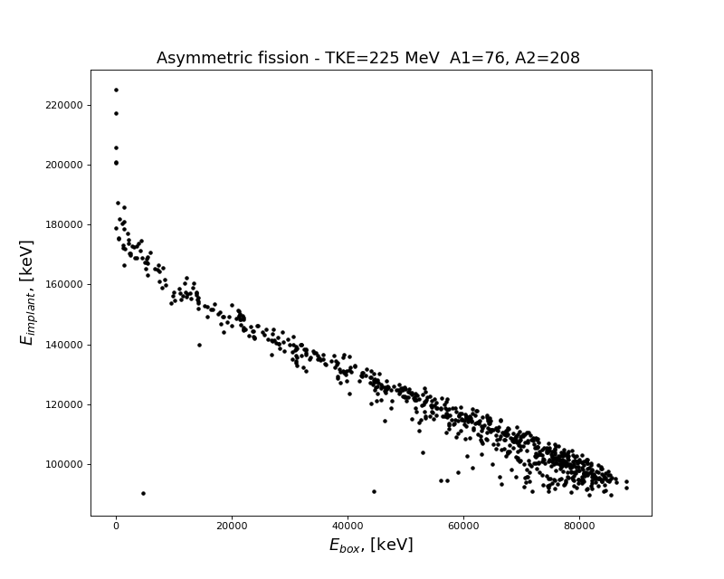

```
For N=2500 runs
```

```python
plt.figure(num=None, figsize=(10, 8), dpi=80, facecolor='w', edgecolor='k')
plt.plot( df_imp_box.Energy_box, df_imp_box.Energy_imp, '.', color='black');
plt.title('Asymmetric fission - TKE=225 MeV  A1=76, A2=208 ', fontsize=16)
plt.xlabel('$E_{box}$, [keV]', fontsize=16)
plt.ylabel('$E_{implant}$, [keV]', fontsize=16)
plt.savefig('output/asymmetric_255_76_208_imp_box.eps', format='eps', dpi=300)
print("For N=2500 runs")
```

The plot above shows the case of *asymmetric fission* with TKE of 225 MeV and two fission products 'light' **Zn-76** and 'heavy' **Pb-208**. Their initial kinetic energy in the simulation was set to be 164.7887 MeV and 60.2113 MeV respectively. Only events where energy was deposited both on the implantation and box detectors are plotted.

From the plot it is clear that 'heavy' fission product always gets fully stopped in the implantation detector. As for 'light' fission product - it losses part of its energy in the implantation detector and therefore, box detectors do not register full its intitial kinetic energy of 165 MeV.

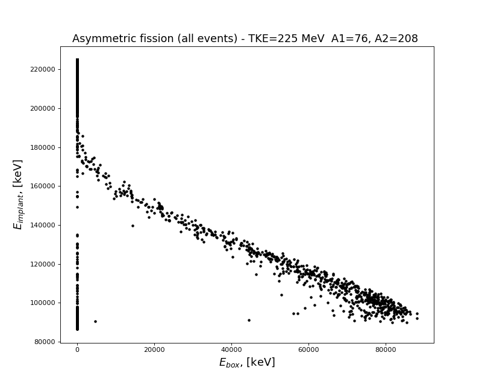

```
For N=2500 runs
```

```python
plt.figure(num=None, figsize=(10, 8), dpi=80, facecolor='w', edgecolor='k')
plt.plot( df_imp_box_all.Energy_box, df_imp_box_all.Energy_imp, '.', color='black');
plt.title('Asymmetric fission (all events) - TKE=225 MeV  A1=76, A2=208 ', fontsize=16)
plt.xlabel('$E_{box}$, [keV]', fontsize=16)
plt.ylabel('$E_{implant}$, [keV]', fontsize=16)
plt.savefig('output/asymmetric_255_76_208_imp_box_all.eps', format='eps', dpi=300)
print("For N=2500 runs")
```

The plot above shows the same case of *asymmetric fission* with TKE of 225 MeV and two fission products 'light' Zn-76 and 'heavy' Pb-208. This time the plot includes **all events** - even when box detectors were not hit.

Multiple values of energies deposited in implantation detector E_box = 0 keV (vox not hit) are shown on the figure. Those values represent sum of energy deposited by 'light' and 'heavy' fission products in the implantation detector. The highest value for such case is 225 MeV - both fragments were completely stopped witin the implantation detector. It is expected for the case when both fragments were emitted with the direction of their momentum along the detector. Values of the sum that are less than 225 MeV in the implant can be explained with the fact that 'light' fission product is emitted to the back of the detector and thus its full energy is not being recorded.

# Results of all simulations

## Plot selected simulation

Make indifidual plot with results of simulation of interest based on **TKE**, **A1** and **A2**:

```python
from ipywidgets import interact, interactive, fixed

def plot_cos_decay(TKE, A):
    print(TKE)
    print(A[0])
    print(A[1])
    E_box, E_imp = select_implant_box_energy(data, TKE, A[0], A[1])
    plt.figure(num=None, figsize=(10, 8), dpi=80, facecolor='w', edgecolor='k')
    plt.plot( E_box, E_imp, '.', color='black');
    plt.title(' TKE={} MeV  A1={}, A2={} '.format(TKE, A[0], A[1]), fontsize=16)
    plt.xlabel('$E_{box}$, [MeV]', fontsize=16)
    plt.ylabel('$E_{implant}$, [MeV]', fontsize=16)
    plt.savefig('output/fission_{}_{}_{}.eps'.format(TKE, A[0], A[1]), format='eps', dpi=300)


interactive_plot = interactive(plot_cos_decay, TKE=[225, 250, 275], A=[('142 142', [142, 142]), ('109 175', [109, 175]), ('76 208', [76, 208])])
interactive_plot.children[0].description=r'$TKE$' # slider
interactive_plot.children[1].description=r'$A$' # slider
interactive_plot
```

## Plots of all simulations

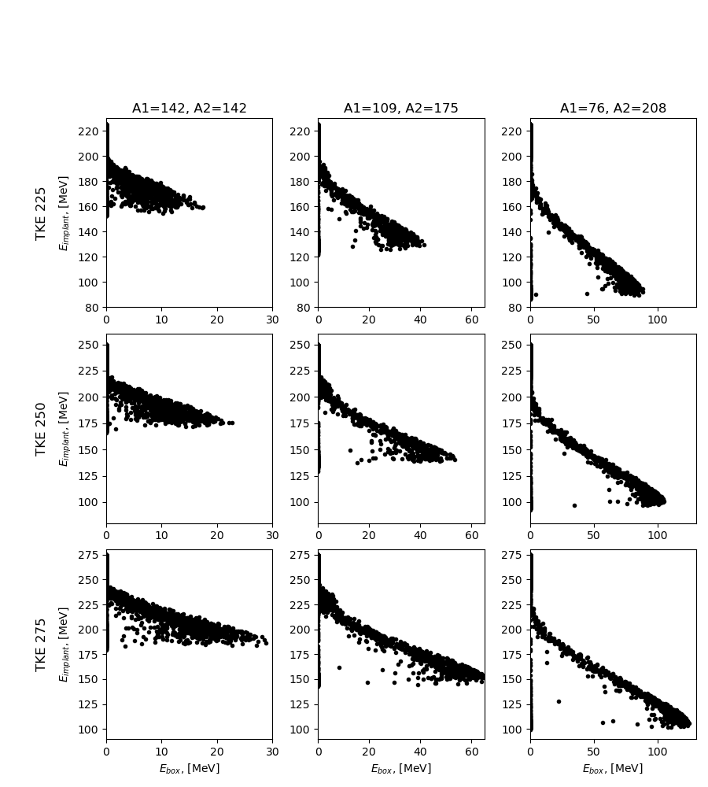

```python
fig, axs = plt.subplots(3, 3, figsize=(9,10))

TKE = [225, 250, 275]
A = [[142,142],[109,175],[76,208]]

# Fill plots
for i, E in enumerate(TKE):
    for j, Ax in enumerate(A):
        E_box, E_imp = select_implant_box_energy(data, E, Ax[0], Ax[1])
        axs[i, j].plot(E_box, E_imp, '.', color='black')

# Label all plots
for i in range(3):
    axs[i, 0].set(ylabel="$E_{implant}$, [MeV]")
    axs[-1, i].set(xlabel="$E_{box}$, [MeV]")

# Add specific labels to all rows and columns
cols = ['A1=142, A2=142', 'A1=109, A2=175', 'A1=76, A2=208']
rows = ['TKE {}'.format(row) for row in ['225', '250', '275']]
pad = 5 # in points
for ax, col in zip(axs[0], cols):
    ax.annotate(col, xy=(0.5, 1), xytext=(0, pad),
                xycoords='axes fraction', textcoords='offset points',
                size='large', ha='center', va='baseline')

for ax, row in zip(axs[:,0], rows):
    ax.annotate(row, xy=(0, 0.5), xytext=(-ax.yaxis.labelpad - pad, 0),
                xycoords=ax.yaxis.label, textcoords='offset points',
                size='large', ha='right',rotation=90, va='center')

# Set x and y lims for all plots
x_lims = [[0,30], [0, 65], [0, 130]]
y_lims = [[80, 230], [80, 260], [90, 280]]
for i in range(len(x_lims)):
    for ax in axs[i]:
        ax.set_ylim(y_lims[i])
    for ax in axs[:, i]:
        ax.set_xlim(x_lims[i])


fig.tight_layout()
fig.subplots_adjust(left=0.15, top=0.85)
fig.savefig('output/fission_composite_plot.eps', format='eps', dpi=300)
```

# Conclusion

The composite plot from the previous cell compares the case of **symmetric fission** (A1/A2 = 1) to two cases of **asymmetric fission** (A1/A2 = 0.37 and 0.62). The latter one includes Pb-208 as one of its fission products. One can clearly distinguish between the asymmetric and symmetric cases from the figure. Thus, with the assumptions and conditions used for the Geant4 simulation, a conclusion can be made that TASISpec set-up should be sensitive to asymmetric fission during real experiments, including the case when Pb-208 is a fission product.

However, the statistics in the Geant4 simulation (2500 runs) is a lot higher than what one has with super heavy experiments (up to 30 events per experiment).

Additionally, analysing pixel-pixel combinations individually is foreseen to better restrict the results. And including uncertainties is essential to provide a conclusion with confidence